## Machine Learning Project : Predicting Wellness factor of Human Activity Recognition research

#### By : Narendra S. Shukla (September 2015)

### Executive Summary :

Using devices such as **Jawbone Up, Nike FuelBand, and Fitbit** it is now possible to collect a large amount of data about personal activity. Often, the emphasis is on **how** much of a particular activity is done, rather than **how well** it is done. In this exercise, 6 young health participants were asked to perform one set of 10 repetitions of the Unilateral Dumbbell Biceps Curl in five different fashions: exactly according to the specification **(Class A)**, throwing the elbows to the front **(Class B)**, lifting the dumbbell only halfway **(Class C)**, lowering the dumbbell only halfway **(Class D)** and throwing the hips to the front **(Class E)**. The excercise information is captured as **19622** observations of **160** variables. Our objective is to **predict the manner** in which they did the exercise

### Tidying the Data & Exploratory Data Analysis

We first start by loading the data.

```r
build <- read.csv("./pml-training.csv", header=T,  sep=",", na.strings=c("NA",""),
                stringsAsFactors=FALSE)
build$classe <- factor(build$classe)
library(caret)
inTrain <- createDataPartition(y=build$classe, p=0.75, list=FALSE)
training <- build[inTrain,]
validation <- build[-inTrain,]
```

We notice that there are quite a few columns with NAs. We retain only those columns where NAs are less than or equal to 5%. We also remove {X} and {user_name} columns.

```r
trainingNew <- training[, colSums(is.na(training)) <= (0.05*nrow(training))]
trainingNew <- trainingNew[,(3:60)]
trainingNew$new_window <- factor(trainingNew$new_window)
```

We now plot a chart of **roll_belt** and **pitch_forearm** to see how response variable **classe** is distributed. (Similar analysis can be performed on other predictor variables),

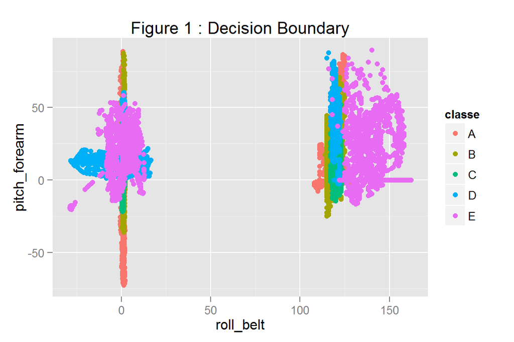

```r
library(ggplot2)
qplot(roll_belt, pitch_forearm, colour=classe, data=trainingNew, main="Figure 1 : Decision Boundary")
```

We notice that the decision boundary is highly **Non-Linear**. So, when we run SVM, as shown below, we shall use **Radial** kernel.

### Model Training, Prediction Accuracy, Out of Sample Error

Now we start applying models to training data. We shall apply 6 models.

1. **Single Tree Model :** Easy to explain. Better graphical display and interpretability. Sometimes lack predictive accuracy. May overfit training data
2. **Single Tree Model with Repeated Cross-Validation :** Provide better Bias-Variance Trde-Off. Provide reduced Test Error Rate.
3. **Linear Discriminant Analysis :** Assumes Multivariate Gaussian distribution for each class, with Class-specific Mean Vector and Common Co-Variance matrix. Uses Bayes Theorem for Classification
4. **Random Forest :** Extension of Bagging Model, with Predictor sub-set resampling at every split. Reduction in Variance is obtained by de-correlating the trees
5. **Support Vector Machines :** One of the best out-of-the-box classifiers. Uses Maximum Margin Classifier with separating hyperplane. SVM uses kernels to enlarge feature space. Only Support-Vectors participate in Classification
6. **Boosting :** Statistical Learning method that learns slowly by fitting small trees to the residuals and Applying weights. Does not use Bootstrap Sampling. Each tree depends upon previously grown tree

### Single Tree Model

```r
tree.model <- train(classe ~ .,method="rpart",data=trainingNew)
save(tree.model,file="treemodel.rda")
```

This is how the tree looks like,

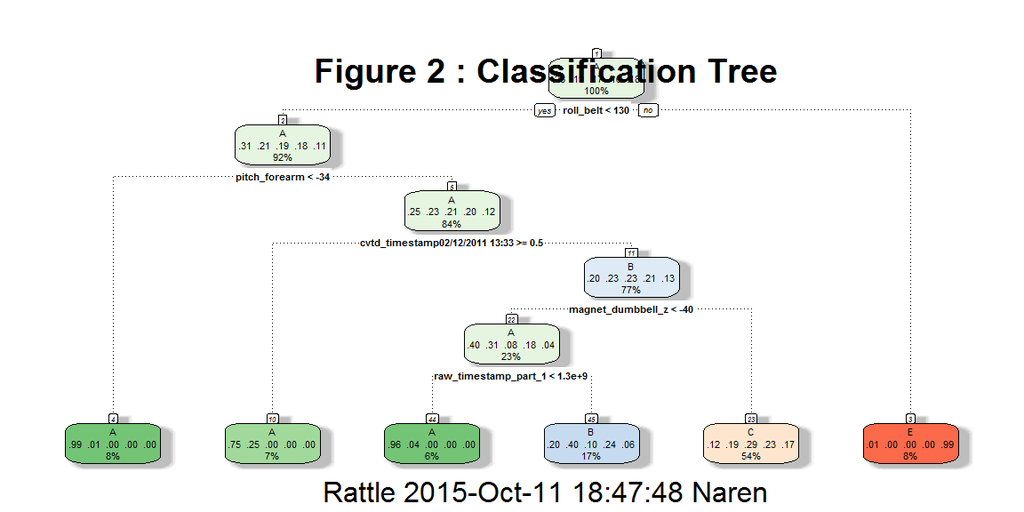

```r
library(rattle)
library(rpart.plot)
load("treemodel.rda")
fancyRpartPlot(tree.model$finalModel,main="Figure 2 : Classification Tree")
```

Now we apply this model to **validation** data-set,

```r
predTree <- predict(tree.model,validation)
confusionMatrix(predTree, validation$classe)$table
```

```
##           Reference
## Prediction   A   B   C   D   E
##          A 905  96   0   0   0
##          B 180 327  82 216  48
##          C 306 526 773 588 426
##          D   0   0   0   0   0
##          E   4   0   0   0 427
```

```r
confusionMatrix(predTree, validation$classe)$overall[1]
```

```
##  Accuracy
## 0.4959217
```

The confusion matrix shows **49.59%** accuracy. Out of Sample error is **50.41%**. The **Out of Sample** error rate is calculated as **(100 - Accuracy)**. We can definitely do better.

### Single Tree Model with Repeated Cross-Validation

We shall use **10 fold cross-validation, repeated 3 times**.

```r
cvCtrl <- trainControl(method ="repeatedcv", repeats = 3)
tree.model2 <- train(classe ~ ., method="rpart",
                         data=trainingNew, tuneLength = 30, trControl=cvCtrl)
save(tree.model2,file="treemodelcv.rda")
```

Applying this model to **validation** data-set,

```r
load("treemodelcv.rda")
predTree2 <- predict(tree.model2,validation)
confusionMatrix(predTree2, validation$classe)$table
```

```
##           Reference
## Prediction    A    B    C    D    E
##          A 1372   74    1   13    0
##          B   15  837   41    8   13
##          C    4   30  804   15    1
##          D    0    8    9  768   17
##          E    4    0    0    0  870
```

```r
confusionMatrix(predTree2, validation$classe)$overall[1]
```

```
##  Accuracy
## 0.9484095
```

The confusion matrix shows **94.84%** accuracy. Out of Sample error is **5.16%**.

### Linear Discriminant Analysis

```r
lda.model <- train(classe ~ ., method="lda",data=trainingNew)
save(lda.model,file="ldamodel.rda")
```

Now apply this model to **validation** data-set,

```r
load("ldamodel.rda")
predLDA <- predict(lda.model,validation)
confusionMatrix(predLDA, validation$classe)$table
```

```
##           Reference
## Prediction    A    B    C    D    E
##          A 1262  109    1    0    0
##          B  115  715   77    0    0
##          C   17  119  752   75    1
##          D    0    6   23  684   92
##          E    1    0    2   45  808
```

```r
confusionMatrix(predLDA, validation$classe)$overall[1]
```

```
##  Accuracy
## 0.8607259
```

The confusion matrix shows **86.07%** accuracy. Out of Sample error is **13.93%**. So Cross-Validated SingleTree model actually did better. Let us continue exploring other models.

### Random Forest

Let us apply **10 fold cross-validation** here,

```r
rf.model <- train(classe ~ ., method="rf",
                    data=trainingNew, trControl=trainControl(method="cv",number=10),
                    prox=TRUE, allowParallel=TRUE)
save(rf.model,file="rfmodelcv.rda")
```

Let us see how the model looks,

```r
load("rfmodelcv.rda")
rf.model
```

```
## Random Forest
##
## 14718 samples
##    57 predictor
##     5 classes: 'A', 'B', 'C', 'D', 'E'
##
## No pre-processing
## Resampling: Cross-Validated (10 fold)
## Summary of sample sizes: 13245, 13248, 13246, 13246, 13246, 13246, ...
## Resampling results across tuning parameters:
##
##   mtry  Accuracy   Kappa      Accuracy SD   Kappa SD
##    2    0.9934766  0.9917470  0.0027441788  0.003473413
##   38    0.9993204  0.9991404  0.0008477900  0.001072242
##   75    0.9989806  0.9987106  0.0008010334  0.001013103
##
## Accuracy was used to select the optimal model using  the largest value.
## The final value used for the model was mtry = 38.
```

Let us plot the **Variable Importance** now,

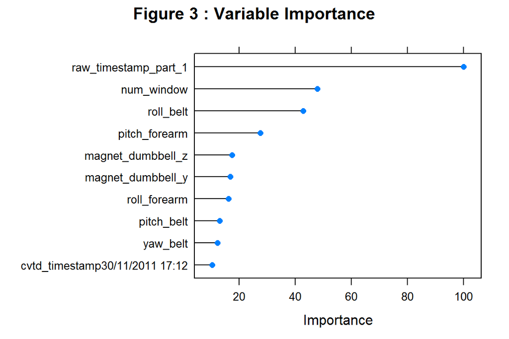

```r
plot(varImp(rf.model),top=10,main="Figure 3 : Variable Importance")
```

We see the **Top 10** most important variables used by this model.

Let us use this model against **validation** data-set,

```r
predRF <- predict(rf.model,validation)
confusionMatrix(predRF, validation$classe)$table
```

```
##           Reference
## Prediction    A    B    C    D    E
##          A 1395    0    0    0    0
##          B    0  949    1    0    0
##          C    0    0  854    0    0
##          D    0    0    0  804    0
##          E    0    0    0    0  901
```

```r
confusionMatrix(predRF, validation$classe)$overall[1]
```

```
##  Accuracy
## 0.9997961
```

The confusion matrix shows **99.98%** accuracy. Out of Sample error is **0.02%**. This is, by far, the best result we got so far.

### Support Vector Machines

For this iteration of SVM, we use **radial** kernal with cost **1** and gamma **0.1**,

```r
library (e1071)
svm.model <- svm(classe ~ ., data=trainingNew , kernel ="radial", cost =1, gamma=0.1 )
save(svm.model,file="svmmodel.rda")
```

This is how the model looks,

```r
load("svmmodel.rda")
svm.model
```

```
##
## Call:
## svm(formula = classe ~ ., data = trainingNew, kernel = "radial",
##     cost = 1, gamma = 0.1)
##
##
## Parameters:
##    SVM-Type:  C-classification
##  SVM-Kernel:  radial
##        cost:  1
##       gamma:  0.1
##
## Number of Support Vectors:  7042
```

Now let us apply this model to **validation** data-set,

```r
library (e1071)
predSVM <- predict(svm.model,validation)
confusionMatrix(predSVM, validation$classe)$table
```

```
##           Reference
## Prediction    A    B    C    D    E
##          A 1392    5    0    0    0
##          B    3  943    1    0    0
##          C    0    1  853   31    0
##          D    0    0    0  773    1
##          E    0    0    1    0  900
```

```r
confusionMatrix(predSVM, validation$classe)$overall[1]
```

```
##  Accuracy
## 0.9912316
```

The confusion matrix shows **99.12%** accuracy. Out of Sample error is **0.88%**. Not Bad.

### Boosting

We run our last model now.

```r
boost.model <- train(classe ~ ., method="gbm",data=trainingNew,verbose=FALSE)
save(boost.model,file="boostmodel.rda")
```

Model uses **n.trees = 150, interaction.depth = 3, shrinkage = 0.1 and n.minobsinnode = 10**.

Now let us apply this model to **validation** data-set,

```r
load("boostmodel.rda")
predBoost <- predict(boost.model,validation)
confusionMatrix(predBoost, validation$classe)$table
```

```
##           Reference
## Prediction    A    B    C    D    E
##          A 1395    0    0    0    0
##          B    0  948    1    0    0
##          C    0    0  850    0    0
##          D    0    1    4  804    0
##          E    0    0    0    0  901
```

```r
confusionMatrix(predBoost, validation$classe)$overall[1]
```

```
##  Accuracy
## 0.9987765
```

The confusion matrix shows **99.88%** accuracy. Out of Sample error is **0.12%**. This, again, turns out to be one of the **best** models.

### Selecting the FINAL MODEL

Let us plot ROC curves for all models together.

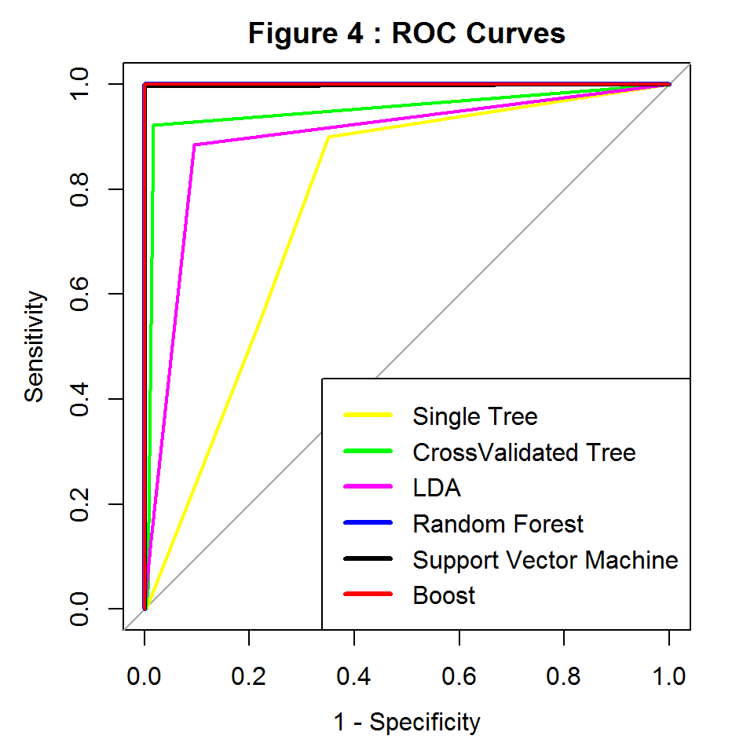

```r
library(pROC)
plot.roc(x = validation$classe, predictor = as.numeric(predTree), col="yellow", legacy.axes=TRUE,
          main="Figure 4 : ROC Curves")
plot.roc(x = validation$classe, predictor = as.numeric(predTree2), col="green",add=TRUE)
plot.roc(x = validation$classe, predictor = as.numeric(predLDA), col="magenta",add=TRUE)
plot.roc(x = validation$classe, predictor = as.numeric(predRF), col="blue",add=TRUE, lwd=3)
plot.roc(x = validation$classe, predictor = as.numeric(predSVM), col="black",add=TRUE)
plot.roc(x = validation$classe, predictor = as.numeric(predBoost), col="red",add=TRUE)

legend("bottomright", legend=c("Single Tree","CrossValidated Tree", "LDA", "Random Forest",
                               "Support Vector Machine", "Boost"),
       col=c("yellow", "green", "magenta", "blue", "black", "red"), lwd=3)
```

As you can see, **Random Forest** and **Boost** models have best ROC curves. Followed by **SVM**.

We select **Random Forest Model** as our final choice.

Now we apply our final model to **testing** data-set,

```r
testing <- read.csv("./pml-testing.csv", header=T,  sep=",", na.strings=c("NA",""),
                 stringsAsFactors=FALSE)
predFinal <- as.character(predict(rf.model,testing))
if (!file.exists("results")) {dir.create("./results")}
pml_write_files = function(x){
        n = length(x)
        for(i in 1:n){
                filename = paste0("./results/problem_id_", i, ".txt")
                write.table(x[i], file = filename, quote = FALSE, row.names = FALSE, col.names = FALSE)
        }
}
pml_write_files(predFinal)
```

### Conclusion

Human Activity Recognition - **HAR** - has emerged as a key research area in the last few years. Based on exercise execution method of participants, it is now possible to **Classify** their exercise execution **Quality**. This **How Well** approach can provide useful information to a large variety of applications, such as **sports training**.

### References

1. This dataset is licensed under the Creative Commons license (CC BY-SA). Read more: http://groupware.les.inf.puc-rio.br/har#ixzz3mf4CHT6z
2. SVM Model details are acquired from **An Introduction to Statistical Learning with Applications in R** . Read more: http://www-bcf.usc.edu/~gareth/ISL/